# IPM Kalimantan Timur 2010-2024

Fazila Alya Dilta Hareer G1401231007

2025-09-04

```r
# memanggil library yang dibutuhkan
library(readxl)
```

```r
library(ggplot2)
library(dplyr)
library(lmtest)
library(TTR)
library(forecast)
library(orcutt)
library(HoRM)
```

## Input Data

data yang digunnakan yaitu IPM (Indeks Pembangunan Manusia) Provinsi Kalimantan Timur

```r
# membaca data dari file Excel
data <- read_excel("C:\\Users\\ASUS\\Documents\\data IPM.xlsx")
data
```

```
## # A tibble: 15 × 2
##    Tahun   IPM
##    <dbl> <dbl>
##  1  2010  71.3
##  2  2011  72.0
##  3  2012  72.6
##  4  2013  73.2
##  5  2014  73.8
##  6  2015  74.2
##  7  2016  74.6
##  8  2017  75.1
##  9  2018  75.8
## 10  2019  76.6
## 11  2020  76.2
## 12  2021  76.9
## 13  2022  77.4
## 14  2023  78.2
## 15  2024  78.8
```

```r
# melihat struktur data
str(data)
```

```
## tibble [15 × 2] (S3: tbl_df/tbl/data.frame)
##  $ Tahun: num [1:15] 2010 2011 2012 2013 2014 ...
##  $ IPM  : num [1:15] 71.3 72 72.6 73.2 73.8 ...
```

## Eksplorasi Data

```r
data.ts <- ts(data$IPM, start = c(2010), frequency = 1)
data.ts
```

```
## Time Series:
## Start = 2010
## End = 2024
## Frequency = 1
##  [1] 71.31 72.02 72.62 73.21 73.82 74.17 74.59 75.12 75.83 76.61 76.24 76.88
## [13] 77.44 78.20 78.83
```

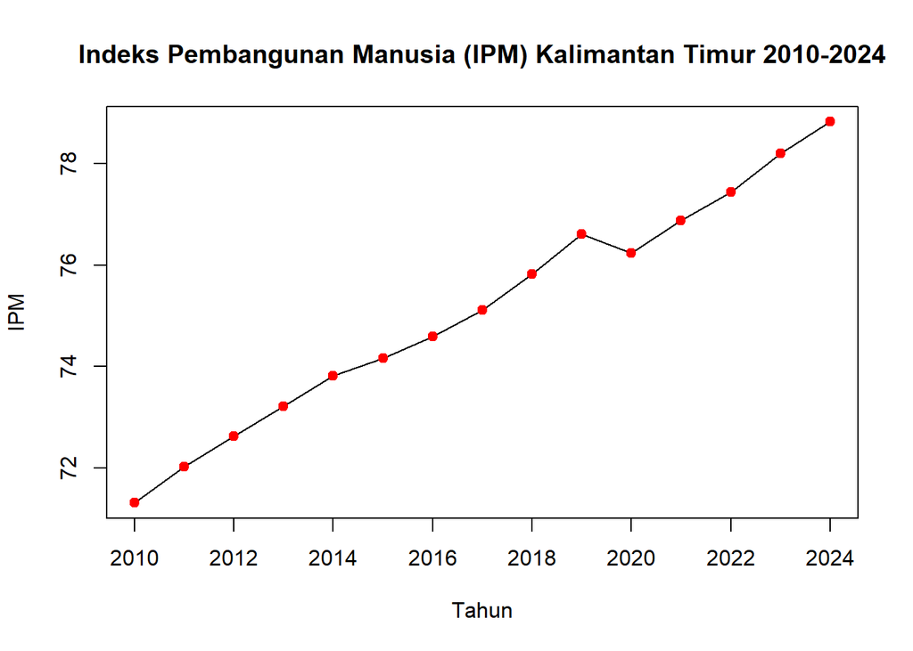

```r
plot(data.ts, main = "Indeks Pembangunan Manusia (IPM) Kalimantan Timur 2010-2024", ylab = "IPM", xlab = "Tahun")
points(data.ts, col = "red", pch = 19)
```

## Double Moving Average (DMA)

```r
dt.sma <- SMA(data.ts, n=3)
dma <- SMA(dt.sma, n = 3)
At <- 2*dt.sma - dma
Bt <- 2/(3-1)*(dt.sma - dma)
dt.dma<- At+Bt
dt.ramal<- c(NA, dt.dma)

t = 1:5
f = c()

for (i in t) {
  f[i] = At[length(At)] + Bt[length(Bt)]*(i)
}

dt.gab <- cbind(aktual = c(data.ts,rep(NA,5)),
                pemulusan1 = c(dt.sma,rep(NA,5)),
                pemulusan2 = c(dt.dma, rep(NA,5)),
                At = c(At, rep(NA,5)),
                Bt = c(Bt,rep(NA,5)),
                ramalan = c(dt.ramal, f[-1]))
dt.gab
```

```
##       aktual pemulusan1 pemulusan2       At        Bt  ramalan
##  [1,]  71.31         NA         NA       NA        NA       NA
##  [2,]  72.02         NA         NA       NA        NA       NA
##  [3,]  72.62   71.98333         NA       NA        NA       NA
##  [4,]  73.21   72.61667         NA       NA        NA       NA
##  [5,]  73.82   73.21667   74.43889 73.82778 0.6111111       NA
##  [6,]  74.17   73.73333   74.82222 74.27778 0.5444444 74.43889
##  [7,]  74.59   74.19333   75.15111 74.67222 0.4788889 74.82222
##  [8,]  75.12   74.62667   75.51111 75.06889 0.4422222 75.15111
##  [9,]  75.83   75.18000   76.20667 75.69333 0.5133333 75.51111
## [10,]  76.61   75.85333   77.12000 76.48667 0.6333333 76.20667
## [11,]  76.24   76.22667   77.17333 76.70000 0.4733333 77.12000
## [12,]  76.88   76.57667   77.29222 76.93444 0.3577778 77.17333
## [13,]  77.44   76.85333   77.45556 77.15444 0.3011111 77.29222
## [14,]  78.20   77.50667   78.56222 78.03444 0.5277778 77.45556
## [15,]  78.83   78.15667   79.45889 78.80778 0.6511111 78.56222
## [16,]     NA         NA         NA       NA        NA 79.45889
## [17,]     NA         NA         NA       NA        NA 80.11000
## [18,]     NA         NA         NA       NA        NA 80.76111
## [19,]     NA         NA         NA       NA        NA 81.41222
## [20,]     NA         NA         NA       NA        NA 82.06333
```

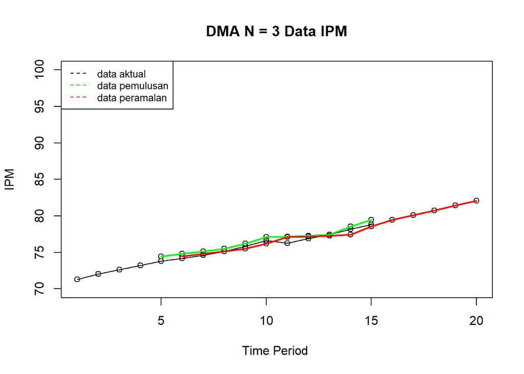

```r
# plot time series
ts.plot(dt.gab[,1], xlab="Time Period ", ylab="IPM",
        main= "DMA N = 3 Data IPM", ylim=c(70,100))
points(dt.gab[,1])
points(dt.gab[,3])
points(dt.gab[,6])
lines(dt.gab[,3],col="green",lwd=2)
lines(dt.gab[,6],col="red",lwd=2)
legend("topleft",c("data aktual","data pemulusan","data peramalan"),
       lty=8, col=c("black","green","red"), cex=0.8)
```

```r
# akurasi metode DMA
error.dma = data.ts-dt.ramal[1:length(data.ts)]
SSE.dma = sum(error.dma[6:length(data.ts)]^2)
MSE.dma = mean(error.dma[6:length(data.ts)]^2)
MAPE.dma = mean(abs((error.dma[6:length(data.ts)]/data.ts[6:length(data.ts)])*100))

akurasi.dma <- matrix(c(SSE.dma, MSE.dma, MAPE.dma))
row.names(akurasi.dma)<- c("SSE", "MSE", "MAPE")
colnames(akurasi.dma) <- c("Akurasi m = 3")
akurasi.dma
```

```
##      Akurasi m = 3
## SSE      1.8997494
## MSE      0.1899749
## MAPE     0.4680575
```

## Double Exponential Smoothing (DES)

```r
# Membagi training dan testing
training<-data[1:10,2]
testing<-data[11:15,2]

# data time series
training.ts<-ts(training)
testing.ts<-ts(testing,start=11)
```

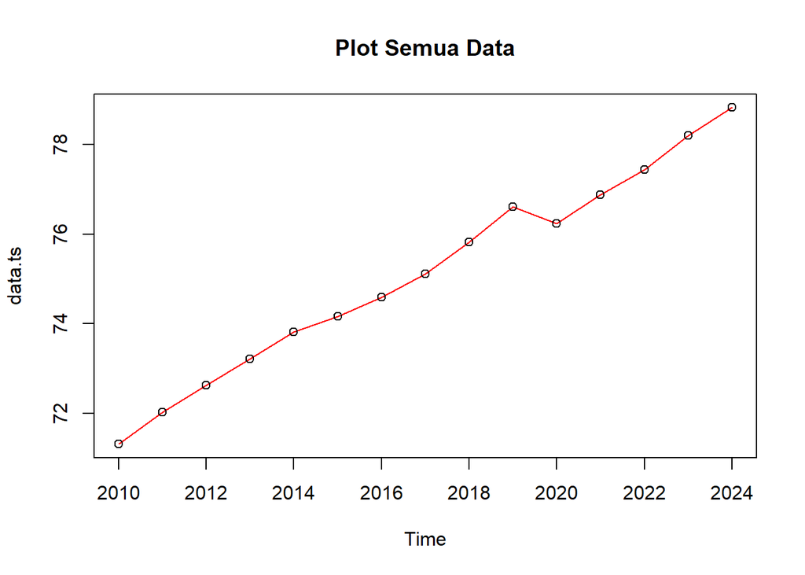

```r
# eksplorasi data
plot(data.ts, col="red",main="Plot Semua Data")
points(data.ts)
```

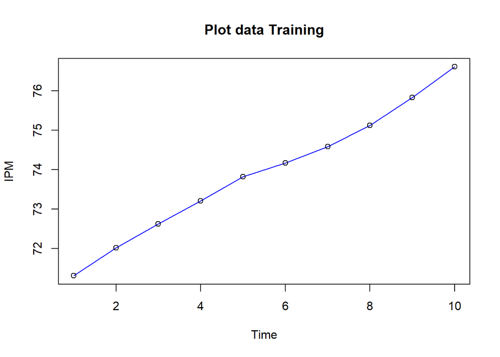

```r
plot(training.ts, col="blue",main="Plot data Training")
points(training.ts)
```

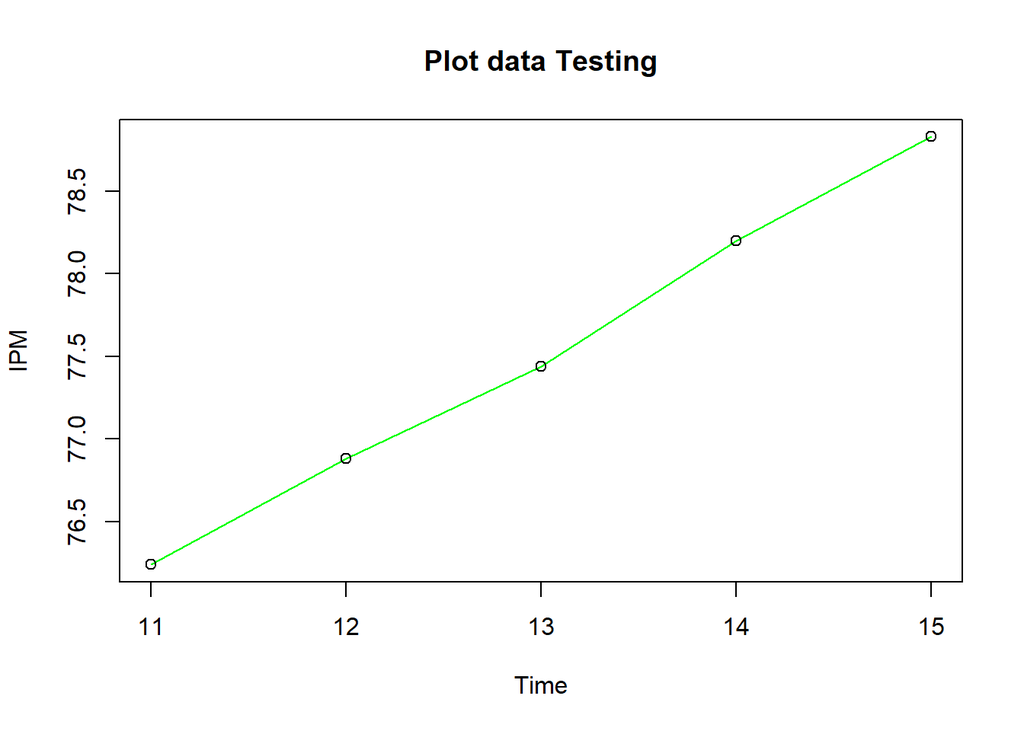

```r
plot(testing.ts, col="green",main="Plot data Testing")
points(testing.ts)
```

# DES dengan Lamda & Gamma Optimum

```r
des.opt<- HoltWinters(training.ts, gamma = FALSE)
des.opt
```

```
## Holt-Winters exponential smoothing with trend and without seasonal component.
##
## Call:
## HoltWinters(x = training.ts, gamma = FALSE)
##
## Smoothing parameters:
##  alpha: 1
##  beta : 1
##  gamma: FALSE
##
## Coefficients:
##    [,1]
## a 76.61
## b  0.78
```

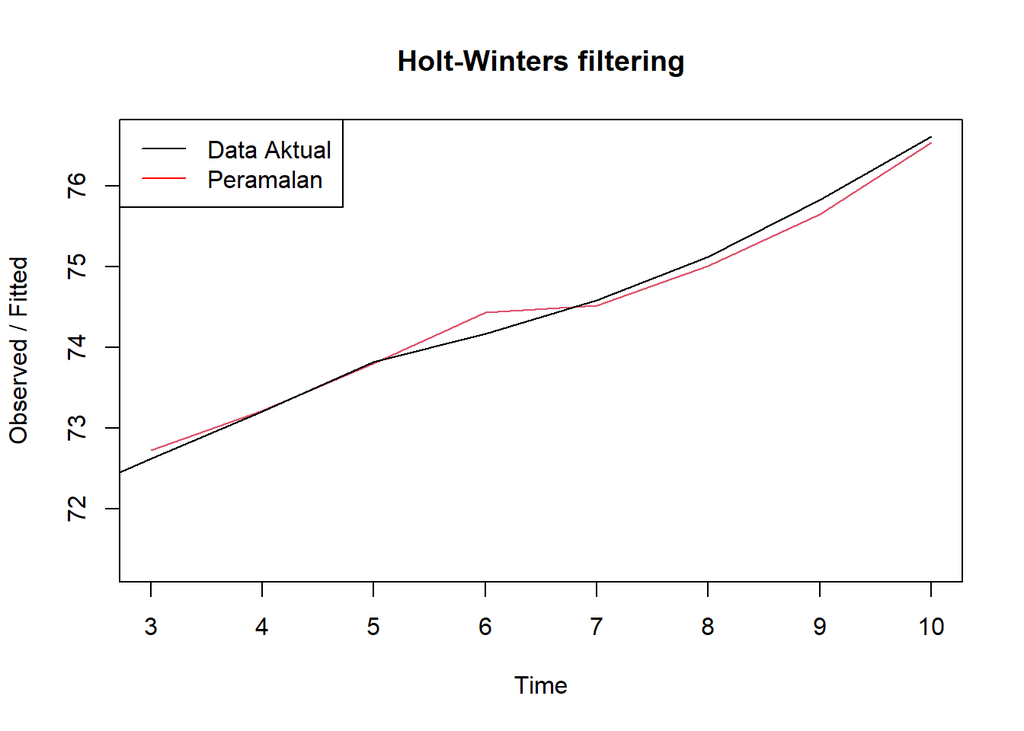

```r
plot(des.opt)
legend("topleft", c("Data Aktual", "Peramalan"), col = c("black", "red"),
       lty = c(1,1))
```

```r
# peramalan
ramalandesopt<- forecast(des.opt, h=7)
ramalandesopt
```

```
##    Point Forecast    Lo 80    Hi 80    Lo 95    Hi 95
## 11          77.39 77.21276 77.56724 77.11894 77.66106
## 12          78.17 77.77368 78.56632 77.56389 78.77611
## 13          78.95 78.28684 79.61316 77.93578 79.96422
## 14          79.73 78.75923 80.70077 78.24533 81.21467
## 15          80.51 79.19557 81.82443 78.49975 82.52025
## 16          81.29 79.59926 82.98074 78.70423 83.87577
## 17          82.07 79.97289 84.16711 78.86275 85.27725
```

# Akurasi Data Training

```r
ssedes.train<-des.opt$SSE
msedes.train<-ssedes.train/length(training.ts)
sisaandes<-ramalandesopt$residuals
head(sisaandes)
```

```
## Time Series:
## Start = 1
## End = 6
## Frequency = 1
##          x
## [1,]    NA
## [2,]    NA
## [3,] -0.11
## [4,] -0.01
## [5,]  0.02
## [6,] -0.26
```

```r
mapedes.train <- sum(abs(sisaandes[3:length(training.ts)]/training.ts[3:length(training.ts)])*100)/length(training.ts)

akurasides.opt <- matrix(c(ssedes.train,msedes.train,mapedes.train))
row.names(akurasides.opt)<- c("SSE", "MSE", "MAPE")
colnames(akurasides.opt) <- c("Akurasi lamda dan gamma optimum")
akurasides.opt
```

```
##      Akurasi lamda dan gamma optimum
## SSE                        0.1345000
## MSE                        0.0134500
## MAPE                       0.1111795
```

# Akurasi Data Testing

```r
selisihdesopt<-ramalandesopt$mean-testing.ts
selisihdesopt
```

```
## Time Series:
## Start = 11
## End = 15
## Frequency = 1
##      testing.ts
## [1,]       1.15
## [2,]       1.29
## [3,]       1.51
## [4,]       1.53
## [5,]       1.68
```

```r
SSEtestingdesopt<-sum(selisihdesopt^2)
SSEtestingdesopt<-SSEtestingdesopt/length(testing.ts)
MAPEtestingdesopt<-sum(abs(selisihdesopt/testing.ts)*100)/length(testing.ts)

akurasiDesTesting <- matrix(c(SSEtestingdesopt,SSEtestingdesopt,MAPEtestingdesopt))
row.names(akurasiDesTesting)<- c("SSE", "MSE", "MAPE")
colnames(akurasiDesTesting) <- c("Akurasi lamda dan gamma optimum")
akurasiDesTesting
```

```
##      Akurasi lamda dan gamma optimum
## SSE                         2.086000
## MSE                         2.086000
## MAPE                        1.844784
```

```r
# Perbandingan Akurasi Metode DMA dan DES
cbind(akurasi.dma, akurasides.opt)
```

```
##      Akurasi m = 3 Akurasi lamda dan gamma optimum
## SSE      1.8997494                       0.1345000
## MSE      0.1899749                       0.0134500
## MAPE     0.4680575                       0.1111795
```

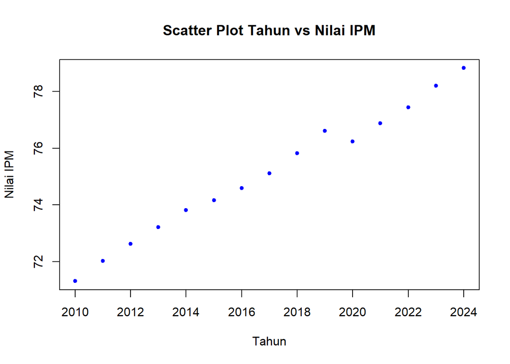

```r
# Scatter Plot Tahun vs Nilai IPM
plot(data$Tahun, data$IPM, pch = 20, col = "blue",
     main = "Scatter Plot Tahun vs Nilai IPM",
     xlab = "Tahun",
     ylab = "Nilai IPM")
```

```r
# Nilai Korelasi
cor(data$Tahun, data$IPM)
```

```
## [1] 0.9950741
```

Berdasarkan scatter plot di atas terlihat adanya hubungan / korelasi positif antara peubah tahun dengan nilai IPM, terlihat titik-titik pada plot yang naik ke arah kanan atas. Hal tersebut juga diperkuat dengan hasil perhitungan aplikasi R di mana didapatkan nilai korelasi sebesar 0.9950741.

## Pemodelan Regresi Linier

```r
# Membuat model regresi linier
model <- lm(IPM ~ Tahun, data = data)
summary(model)
```

```
##
## Call:
## lm(formula = IPM ~ Tahun, data = data)
##
## Residuals:
##      Min       1Q   Median       3Q      Max
## -0.40614 -0.14264  0.02757  0.13393  0.47057
##
## Coefficients:
##              Estimate Std. Error t value Pr(>|t|)
## (Intercept) -946.9167    28.2400  -33.53 5.20e-14 ***
## Tahun          0.5067     0.0140   36.19 1.95e-14 ***
## ---
## Signif. codes:  0 '***' 0.001 '**' 0.01 '*' 0.05 '.' 0.1 ' ' 1
##
## Residual standard error: 0.2343 on 13 degrees of freedom
## Multiple R-squared:  0.9902, Adjusted R-squared:  0.9894
## F-statistic:  1310 on 1 and 13 DF,  p-value: 1.947e-14
```

Model yang dihasilkan adalah yi=-946.9167+0.5067xt Berdasarkan ringkasan model dapat diketahui bahwa hasil uji F memiliki p-value < α (5%). Artinya, minimal terdapat satu variabel yang berpengaruh nyata terhadap model. Hasil uji-t parsial kedua parameter regresi, yaitu intersep dan koefisien regresi juga menunjukkan hal yang sama, yaitu memiliki p-value < α (5%) sehingga nyata dalam taraf 5%. Selanjutnya dapat dilihat juga nilai R2=0.9902. Artinya, sebesar 99.02% keragaman nilai IPM dapat dijelaskan oleh peubah tahun. Hasil ini menunjukkan hasil yang bagus, seolah mendapatkan hasil terbaik. Namun, kita perlu melakukan uji terhadap sisaannya seperti berikut ini.

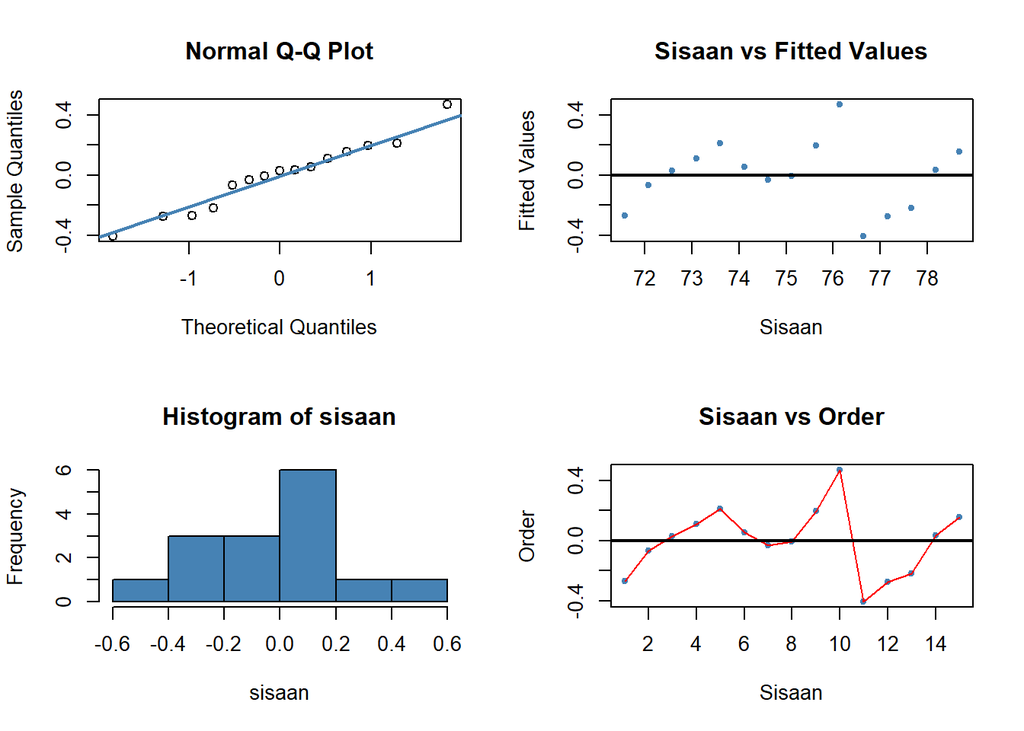

```r
# Sisaan dan fitted value
sisaan <- residuals(model)
fitValue <- predict(model)

# Diagnostik dengan eksploratif
par(mfrow = c(2,2))
qqnorm(sisaan)
qqline(sisaan, col = "steelblue", lwd = 2)
plot(fitValue, sisaan, col = "steelblue", pch = 20, xlab = "Sisaan", ylab = "Fitted Values", main = "Sisaan vs Fitted Values")
abline(a = 0, b = 0, lwd = 2)
hist(sisaan, col = "steelblue")
plot(seq(1,15,1), sisaan, col = "steelblue", pch = 20, xlab = "Sisaan", ylab = "Order", main = "Sisaan vs Order")
lines(seq(1,15,1), sisaan, col = "red")
abline(a = 0, b = 0, lwd = 2)
```

Berdasarkan empat plot di atas, kita bisa menyimpulkan beberapa hal mengenai model yang dianalisis. Dua plot di sisi kiri berkaitan dengan asumsi kenormalan sisaan. Normal Q-Q Plot menunjukkan bahwa titik-titik data tidak sepenuhnya mengikuti garis lurus, meskipun cukup dekat, mengindikasikan bahwa sisaan mendekati sebaran normal namun tidak sepenuhnya normal. Hal ini diperkuat oleh Histogram of sisaan yang terlihat agak miring dan tidak simetris sempurna, sehingga distribusi sisaan tidak bisa dikatakan normal secara penuh.

Sementara itu, dua plot di sisi kanan digunakan untuk memeriksa autokorelasi. Plot Sisaan vs Fitted Values menunjukkan sebaran yang tidak acak karena terlihat adanya pola tertentu di sekitar garis nol, menandakan kemungkinan adanya autokorelasi atau varians yang tidak konstan. Indikasi ini diperkuat oleh plot Sisaan vs Order, yang menampilkan fluktuasi pola yang berulang, mengisyaratkan bahwa nilai sisaan saat ini mungkin dipengaruhi oleh sisaan sebelumnya. Oleh karena itu, diperlukan uji formal lebih lanjut untuk mengonfirmasi kedua temuan ini, seperti uji normalitas sisaan (misalnya, uji Shapiro-Wilk) dan analisis autokorelasi menggunakan plot ACF dan PACF.

```r
# Uji Normalitas Sisaan dengan Shapiro-Wilk
# H0: sisaan mengikuti sebaran normal
# H1: sisaan tidak mengikuti sebaran normal
shapiro.test(sisaan)
```

```
##
##  Shapiro-Wilk normality test
##
## data:  sisaan
## W = 0.97191, p-value = 0.8853
```

```r
ks_test <- ks.test(sisaan, "pnorm", mean = mean(sisaan), sd = sd(sisaan))
print(ks_test)
```

```
##
##  Exact one-sample Kolmogorov-Smirnov test
##
## data:  sisaan
## D = 0.11883, p-value = 0.967
## alternative hypothesis: two-sided
```

Berdasarkan hasil uji formal, yaitu uji Shapiro-Wilk dan Kolmogorov-Smirnov, didapatkan nilai p-value yang lebih besar dari tingkat signifikansi α (0,05 atau 5%). Ini menunjukkan bahwa tidak ada cukup bukti untuk menolak hipotesis nol (H₀). Dengan kata lain, kita dapat menyimpulkan bahwa sisaan (residual) model berdistribusi normal. Selanjutnya, untuk memastikan tidak ada korelasi antar sisaan, akan dilakukan uji autokorelasi menggunakan uji Durbin-Watson serta analisis visual dengan plot ACF (Autocorrelation Function) dan PACF (Partial Autocorrelation Function).

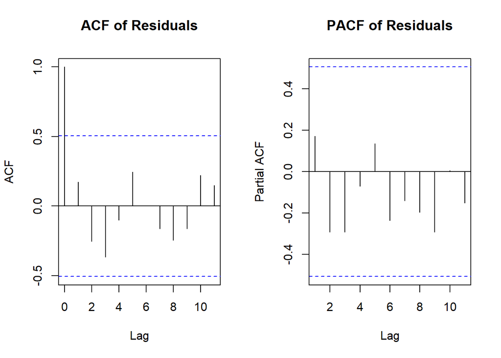

```r
# Plot ACF dan PACF sisaan
par(mfrow = c(1,2))
acf(sisaan, main = "ACF of Residuals")
pacf(sisaan, main = "PACF of Residuals")
```

```r
# Uji Durbin-Watson
# H0: tidak ada autokorelasi
# H1: ada autokorelasi
dwtest(model)
```

```
##
##  Durbin-Watson test
##
## data:  model
## DW = 1.5204, p-value = 0.09748
## alternative hypothesis: true autocorrelation is greater than 0
```

Nilai p−value (0.09748): Nilai ini lebih besar dari tingkat signifikansi yang umum digunakan, yaitu α=0.05. Dalam uji statistik, ketika p−value>α, kita gagal menolak hipotesis nol (H₀). Hipotesis nol pada uji Durbin-Watson menyatakan bahwa tidak ada autokorelasi serial. Dengan demikian, kita tidak memiliki cukup bukti statistik untuk menyatakan bahwa autokorelasi ada.

Nilai Durbin-Watson (DW) (1.5204): Nilai DW berkisar antara 0 hingga 4. Nilai yang mendekati 2 menunjukkan tidak adanya autokorelasi. Nilai yang mendekati 0 mengindikasikan autokorelasi positif, sedangkan nilai yang mendekati 4 mengindikasikan autokorelasi negatif. Nilai DW sebesar 1.5204 cukup dekat dengan 2, yang secara visual mendukung kesimpulan dari p−value bahwa sisaan model cukup acak dan tidak saling berkorelasi.